# Draft genomes of the three northern hemisphere blue mussel species: *Mytilus edulis*, *Mytilus galloprovincialis* and *Mytilus trossulus*

Alexis Simon<sup>1</sup>

Christine Arbiol<sup>1</sup>

Nicolas Bierne<sup>1</sup>

2021-04-28

<sup>1</sup> CNRS, Univ Montpellier, …

`*` Corresponding author: alexis.simon@normalesup.org

Using the 10X chromium long reads technology, we provide draft genomes for three closely related blue mussel species from the *Mytilus* species complex. The objective was to produce affordable genomic resources for population and evolutionary genomic studies. Genomes are fragmented but represent a large portion of the genome, with good sizes and BUSCO scores.

*Keywords*: *Mytilus edulis*, *Mytilus galloprovincialis*, *Mytilus trossulus*, Genome assembly, 10X chromium

# Introduction

# Methods

## Biological material and DNA extraction

One individual for each species of interest was collected and processed fresh.

Whole mussels were placed in 50 mL falcon tubes containing 25 ml of TNES-Urea solution and incubated for 4-6 weeks at room temperature (TNES-Urea: 10 mM Tris-HCl pH 7.4; 120 mM NaCl; 10 mM EDTA pH 8.0; 0.5% SDS; 4 M urea).

After this period of pre-treatment at ambient temperature, proteinase K was added at a final concentration of 150 $\mu$g/mL and the solution was incubated overnight at 56°C.

High Molecular weight genomic DNA was extracted following (From Nakayama et al., 1994, Chromosoma). We used a 15 mL Phase Lock Gel Heavy extraction with 3 steps of phenol/chloroform/isoamylalcool (25/24/1) Tris pH 8,1 followed by 2 chloroform extractions. After the last extraction, the aqueous supernatant was precipitated with 2 volumes of 100% EtOH and the pellet was hooked from the solution with a sterile glass Pasteur pipette. The pellet was rinsed several times in 80% EtOH before being dried at room temperature.

DNA was resuspended with an appropriate volume of biomolecular water at 65°C for several hours, the duration of this incubation depending on the size of the granules. DNA was then stored at 4°C.

Prior to the construction of the DNA libraries, DNA was repaired with NEBNext FFPE DNA Repair Mix according to the manufacturer’s instructions.

## Library preparation and sequencing

The 10X chromium library preparation and sequencing was subcontracted to the MGX platform (Montpellier, France).

They followed 10X Genomics Genome Reagen Kit (*Genome Solution*) protocol to produce the 10X linked reads library using a Chromium microfluidic chip.

The library was sequenced on an Illumina NovaSeq 6000 with an S4 flowcell.

## Draft genome assemblies

- v1: `Supernova` v2.1.1
- v4: `purge_dups` (`longranger align`)
- v5: `agouti` using RNAseq data (`augustus` to get gff3, RNAseq `rcorrector` + `trimgalore` + `bwa-mem2` + merge bams). RNAseq data are from both NCBI and Maurine’s/Erika’s experiments.
- v6: blobtoolkit filtration based on groups

-> gives mtro_01, medu_01, mgal_01

## *M. trossulus* assembly improvement using minion reads and *M. coruscus* assembly

- `LRScaf` using ONT reads (`minimap2` alignment)
- `RagTag` using *M. coruscus* chromosomal assembly
- `Pilon` using PE reads from 10X library (debarcoded + filtered with `fastp`, `bwa-mem2` alignement) + ONT reads

-> gives mtro_02 (tros_v7)

# Results and discussion

## Assembly statistics

| asm | C.L10 | C.L50 | C.N50 | C.gc_content | C.median | C.sequence_count | C.total_bps | S.L10 | S.L50 | S.N50 | S.gc_content | S.median | S.sequence_count | S.total_bps |
| --- | --- | --- | --- | --- | --- | --- | --- | --- | --- | --- | --- | --- | --- | --- |
| coruscus_GCA017311375 | 20 | 261 | 1481111 | 32.44781 | 42077.0 | 6449 | 1566328438 | 1 | 6 | 99542347 | 32.44781 | 21293.0 | 4434 | 1566529938 |
| gallo_GCA900618805 | 505 | 4922 | 77035 | 32.14444 | 39489.0 | 22922 | 1252574651 | 205 | 1903 | 207642 | 32.14444 | 77568.0 | 10577 | 1282208009 |
| gallo_v6 | 1722 | 18455 | 24300 | 32.10198 | 7245.0 | 122807 | 1563256235 | 371 | 4489 | 93841 | 32.10198 | 7443.0 | 62859 | 1658120473 |
| gallo_v7 | 1563 | 16906 | 26323 | 32.10419 | 7475.0 | 115913 | 1564403999 | 1 | 9 | 71952646 | 32.10419 | 4531.0 | 41122 | 1658656017 |
| edu_v6 | 2528 | 26434 | 21931 | 34.56790 | 6283.0 | 178583 | 2026786608 | 728 | 8699 | 63511 | 34.56790 | 6878.0 | 98300 | 2078775992 |
| edu_v7 | 2345 | 24467 | 23624 | 34.57410 | 6477.5 | 169324 | 2026314473 | 2 | 415 | 228263 | 34.57410 | 4999.0 | 73616 | 2076685641 |
| tros_v6 | 1602 | 17538 | 25815 | 32.08765 | 7999.5 | 115574 | 1582506385 | 272 | 4036 | 96269 | 32.08765 | 8153.0 | 59809 | 1666485005 |
| tros_v7 | 1442 | 15862 | 29157 | 32.08803 | 8961.0 | 105892 | 1626074252 | 1 | 9 | 77102752 | 32.08803 | 6164.5 | 28220 | 1764246486 |

## BUSCO scores

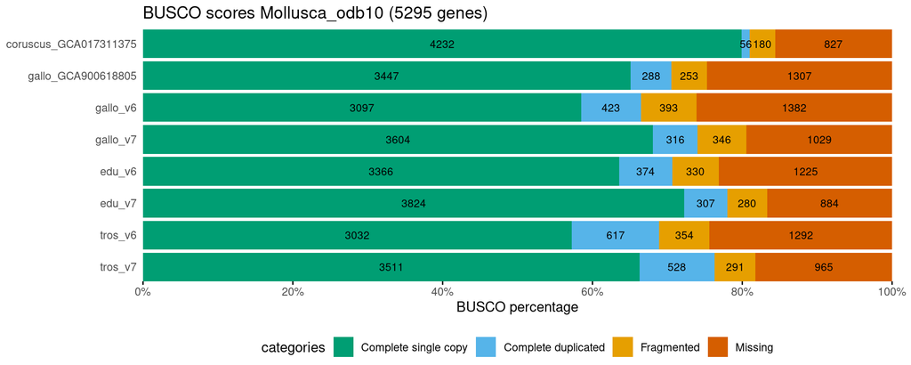

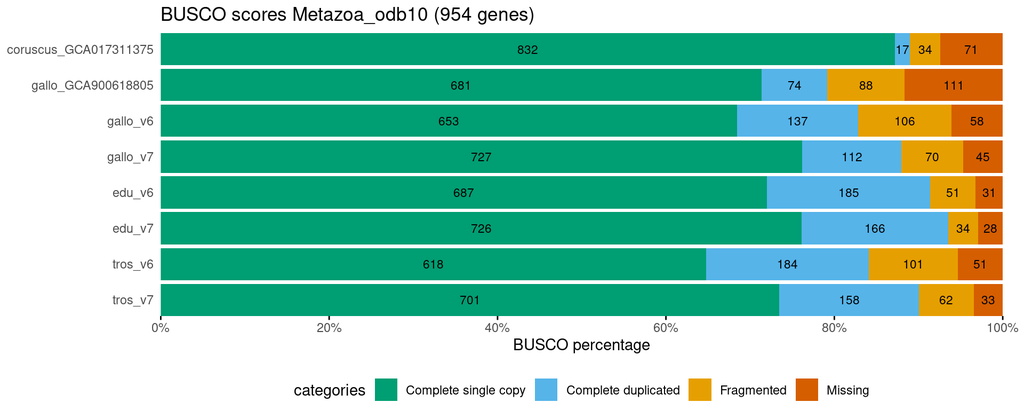

# Conclusion

# Acknowledgement

# References

[output not shown]

[output not shown]

[figure not shown]

[figure not shown]

# Other things we tried

## Raw reads filtration

[output not shown]

[figure not shown]